# Tugas MPDW Praktikum 3 Wildy

Wildy Fahmi Rosyidi G1401231066

2025-09-14

```r
library(dLagM)
library(dynlm)
library(MLmetrics)
library(lmtest)
library(car)
library(psych)
library(dplyr)
library(lmtest)
library(HoRM)
```

## Data

```r
data_mpdw3 <- read.csv("C:/Users/W/Downloads/NewDelhi_Air_quality.csv", header = TRUE, sep = ",", stringsAsFactors = FALSE)
data_mpdw3
```

```
##     X  AQI       CO      datetime        no2       o3      pm10     pm25
## 1   0 30.2 198.6027 2022-10-21:18 0.04685717 55.78995 10.486722 5.637410
## 2   1 28.2 197.6013 2022-10-21:19 0.04645554 54.93164 10.719325 4.618169
## 3   2 26.6 198.6027 2022-10-21:20 0.04685717 54.64554 11.155578 3.520902
## 4   3 25.0 201.9405 2022-10-21:21 0.04819594 55.07469 11.116206 2.225919
## 5   4 26.0 205.2784 2022-10-21:22 0.04886533 55.78995 10.405250 1.979471
## 6   5 26.0 208.6163 2022-10-21:23 0.05020411 56.50520  9.402518 1.792677
## 7   6 26.0 208.6163 2022-10-22:00 0.05020411 55.78995  8.482822 1.752237
## 8   7 24.0 205.2784 2022-10-22:01 0.05020411 52.92892  7.586667 1.858459
## 9   8 23.0 200.2716 2022-10-22:02 0.04685717 50.06790  7.636587 2.208076
## 10  9 24.0 196.9338 2022-10-22:03 0.04417961 51.49841  8.487648 2.476681
## 11 10 25.0 198.6027 2022-10-22:04 0.04284084 53.64418  9.357371 2.585729
## 12 11 26.0 200.2716 2022-10-22:05 0.04049798 55.78995 10.338728 2.390081
## 13 12 27.0 203.6095 2022-10-22:06 0.04016329 59.36623 10.523314 2.086022
## 14 13 29.0 205.2784 2022-10-22:07 0.03882451 62.22725 10.635970 1.937047
```

[output cut: 131 more lines]

```r
data_tanpa_waktu <- data_mpdw3[ , -c(1, 4, 10, 11, 12)]
data_tanpa_waktu
```

```
##     AQI       CO        no2       o3      pm10     pm25       so2
## 1  30.2 198.6027 0.04685717 55.78995 10.486722 5.637410 0.3874302
## 2  28.2 197.6013 0.04645554 54.93164 10.719325 4.618169 0.4097819
## 3  26.6 198.6027 0.04685717 54.64554 11.155578 3.520902 0.4023313
## 4  25.0 201.9405 0.04819594 55.07469 11.116206 2.225919 0.3762543
## 5  26.0 205.2784 0.04886533 55.78995 10.405250 1.979471 0.3390014
## 6  26.0 208.6163 0.05020411 56.50520  9.402518 1.792677 0.3129244
## 7  26.0 208.6163 0.05020411 55.78995  8.482822 1.752237 0.3129244
## 8  24.0 205.2784 0.05020411 52.92892  7.586667 1.858459 0.3427267
## 9  23.0 200.2716 0.04685717 50.06790  7.636587 2.208076 0.3948808
## 10 24.0 196.9338 0.04417961 51.49841  8.487648 2.476681 0.4284084
## 11 25.0 198.6027 0.04284084 53.64418  9.357371 2.585729 0.4284084
## 12 26.0 200.2716 0.04049798 55.78995 10.338728 2.390081 0.3986061
## 13 27.0 203.6095 0.04016329 59.36623 10.523314 2.086022 0.3501773
## 14 29.0 205.2784 0.03882451 62.22725 10.635970 1.937047 0.3166497
```

[output cut: 58 more lines]

## Eksplorasi Data & Pemilihan Peubah

Karena peubah Y sudah diketahui (AQI), disini saya ingin memilih peubah X melalui korelasinya. Saya akan buat matriks korelasi dan melihat peubah mana yang paling signifikan dengan peubah Y (AQI)

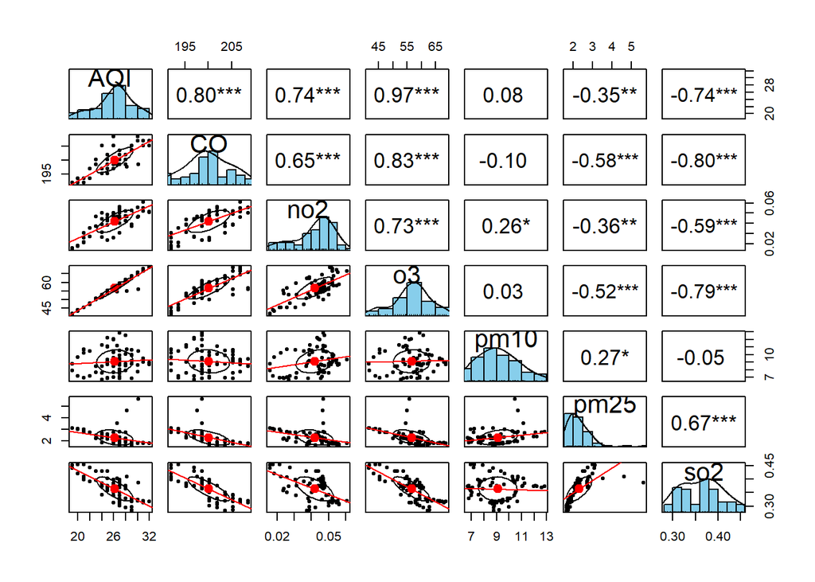

```r
pairs.panels(data_tanpa_waktu,
             method = "pearson",
             hist.col = "skyblue",
             density = TRUE,
             ellipses = TRUE,
             stars = TRUE,
             lm = TRUE)
```

Dari hasil diatas didapat peubah `o3` berpengaruh sangat signifikan terhadap nilai AQI, maka saya akan menggunakan `o3` sebagai peubah X saya.

```r
data_mpdw3_final <- data_mpdw3[ , c(2, 6)]
data_mpdw3_final
```

```
##     AQI       o3
## 1  30.2 55.78995
## 2  28.2 54.93164
## 3  26.6 54.64554
## 4  25.0 55.07469
## 5  26.0 55.78995
## 6  26.0 56.50520
## 7  26.0 55.78995
## 8  24.0 52.92892
## 9  23.0 50.06790
## 10 24.0 51.49841
## 11 25.0 53.64418
## 12 26.0 55.78995
## 13 27.0 59.36623
## 14 29.0 62.22725
```

[output cut: 58 more lines]

```r
str(data_mpdw3_final)
```

```
## 'data.frame':    72 obs. of  2 variables:
##  $ AQI: num  30.2 28.2 26.6 25 26 26 26 24 23 24 ...
##  $ o3 : num  55.8 54.9 54.6 55.1 55.8 ...
```

```r
dim(data_mpdw3_final)
```

```
## [1] 72  2
```

## Pengecekan Autokorelasi

```r
model_awal <- lm(AQI ~ o3, data = data_mpdw3_final)
summary(model_awal)
```

```
##
## Call:
## lm(formula = AQI ~ o3, data = data_mpdw3_final)
##
## Residuals:
##     Min      1Q  Median      3Q     Max
## -0.5039 -0.4436 -0.1381  0.1810  4.3810
##
## Coefficients:
##             Estimate Std. Error t value Pr(>|t|)
## (Intercept)  0.02128    0.73771   0.029    0.977
## o3           0.46241    0.01296  35.685   <2e-16 ***
## ---
## Signif. codes:  0 '***' 0.001 '**' 0.01 '*' 0.05 '.' 0.1 ' ' 1
##
## Residual standard error: 0.7022 on 70 degrees of freedom
## Multiple R-squared:  0.9479, Adjusted R-squared:  0.9472
## F-statistic:  1273 on 1 and 70 DF,  p-value: < 2.2e-16
```

Uji Durbin-Watson dengan :

H0 : Tidak ada autokorelasi. Sisaan saling bebas.

H1 : Ada autokorelasi.

```r
dwtest(model_awal)
```

```
##
##  Durbin-Watson test
##
## data:  model_awal
## DW = 0.54636, p-value = 3.207e-14
## alternative hypothesis: true autocorrelation is greater than 0
```

Meskipun pada hasil summary model awal sebelumnya diketahui kalo model kita terlihat sangat baik dengan R-squared yang mencapai 0.9472 dan nilai `o3` yang signifikan. Tapi pada hasil Durbin-Watson test diketahui bahwa kita menolak H0, yang berarti model kita mengalami autokorelasi.

### Penanganan Autokorelasi

Untuk penanganan nya sendiri saya akan menggunakan metode Hidreth-Lu

```r
hildreth.lu.func <- function(r, model){
  x <- model.matrix(model)[,-1]
  y <- model.response(model.frame(model))
  n <- length(y)
  t <- 2:n
  y <- y[t]-r*y[t-1]
  x <- x[t]-r*x[t-1]

  return(lm(y~x))
}

r <- c(seq(0.1,0.9, by= 0.1))
tab <- data.frame("rho" = r, "SSE" = sapply(r, function(i){deviance(hildreth.lu.func(i, model_awal))}))
round(tab, 4)
```

```
##   rho     SSE
## 1 0.1 12.2977
## 2 0.2 10.2333
## 3 0.3  8.8584
## 4 0.4  8.1728
## 5 0.5  8.1761
## 6 0.6  8.8676
## 7 0.7 10.2462
## 8 0.8 12.3113
## 9 0.9 15.0661
```

Didapat nilai SSE nya terendah antara 0.3 hingga 0.6

```r
rOpt <- seq(0.3,0.6, by= 0.001)
tabOpt <- data.frame("rho" = rOpt, "SSE" = sapply(rOpt, function(i){deviance(hildreth.lu.func(i, model_awal))}))
head(tabOpt[order(tabOpt$SSE),])
```

```
##       rho      SSE
## 151 0.450 8.088418
## 150 0.449 8.088420
## 152 0.451 8.088486
## 149 0.448 8.088489
## 153 0.452 8.088623
## 148 0.447 8.088628
```

Didapat rho dengan nilai SSE terkecil adalah 0.450.

```r
model_hl_mpdw3 <- hildreth.lu(data_mpdw3_final$o3, data_mpdw3_final$AQI, rho = 0.450)
summary(model_hl_mpdw3)
```

```
##
## Call:
## lm(formula = y ~ x)
##
## Residuals:
##     Min      1Q  Median      3Q     Max
## -1.8554 -0.5119 -0.2421  0.5424  2.0723
##
## Coefficients:
##             Estimate Std. Error t value Pr(>|t|)
## (Intercept)  1.44728    0.69783   2.074   0.0418 *
## x            2.06942    0.04825  42.892   <2e-16 ***
## ---
## Signif. codes:  0 '***' 0.001 '**' 0.01 '*' 0.05 '.' 0.1 ' ' 1
##
## Residual standard error: 0.7217 on 69 degrees of freedom
## Multiple R-squared:  0.9639, Adjusted R-squared:  0.9633
## F-statistic:  1840 on 1 and 69 DF,  p-value: < 2.2e-16
```

```r
dwtest(model_hl_mpdw3)
```

```
##
##  Durbin-Watson test
##
## data:  model_hl_mpdw3
## DW = 2.6327, p-value = 0.9958
## alternative hypothesis: true autocorrelation is greater than 0
```

Setelah dilakukan penanganan dengan metode Hildreth-Lu model sudah aman dari autokorelasi.

## Pemodelan Time Series

### Pembuatan Data

Saya akan menambahkan kolom `t`, `AQI - 1` ke dalam data `data_mpdw3_final`

```r
data_mpdw_lag <- data_mpdw3_final %>%
  mutate(
    t = row_number(),
    AQI_1 = lag(AQI, 1)
  ) %>%
  select(t, AQI, AQI_1, o3)
data_mpdw_lag
```

```
##     t  AQI AQI_1       o3
## 1   1 30.2    NA 55.78995
## 2   2 28.2  30.2 54.93164
## 3   3 26.6  28.2 54.64554
## 4   4 25.0  26.6 55.07469
## 5   5 26.0  25.0 55.78995
## 6   6 26.0  26.0 56.50520
## 7   7 26.0  26.0 55.78995
## 8   8 24.0  26.0 52.92892
## 9   9 23.0  24.0 50.06790
## 10 10 24.0  23.0 51.49841
## 11 11 25.0  24.0 53.64418
## 12 12 26.0  25.0 55.78995
## 13 13 27.0  26.0 59.36623
## 14 14 29.0  27.0 62.22725
```

[output cut: 58 more lines]

### Pembagian data

Akan dibagi 80% data latih dan 20% data uji

```r
train_mpdw3 <- data_mpdw_lag[1:58,]
test_mpdw3 <- data_mpdw_lag[59:72,]
```

```r
train_mpdw3_ts <- ts(train_mpdw3)
test_mpdw3_ts <- ts(test_mpdw3)
data_mpdw3_ts <- ts(data_mpdw_lag)
```

## Model Koyck

```r
model_koyck <- koyckDlm(x = train_mpdw3$o3, y = train_mpdw3$AQI)
summary(model_koyck)
```

```
##
## Call:
## "Y ~ (Intercept) + Y.1 + X.t"
##
## Residuals:
##       Min        1Q    Median        3Q       Max
## -1.112282 -0.366467 -0.002877  0.258311  1.106529
##
## Coefficients:
##             Estimate Std. Error t value Pr(>|t|)
## (Intercept)  0.26260    0.93950   0.280    0.781
## Y.1          0.42943    0.08641   4.969 7.14e-06 ***
## X.t          0.25823    0.04259   6.064 1.35e-07 ***
## ---
## Signif. codes:  0 '***' 0.001 '**' 0.01 '*' 0.05 '.' 0.1 ' ' 1
##
## Residual standard error: 0.5239 on 54 degrees of freedom
## Multiple R-Squared: 0.9449,  Adjusted R-squared: 0.9429
## Wald test: 417.1 on 2 and 54 DF,  p-value: < 2.2e-16
##
## Diagnostic tests:
## NULL
##
##                             alpha      beta       phi
## Geometric coefficients:  0.460243 0.2582336 0.4294305
```

```r
AIC(model_koyck)
```

```
## [1] 92.98106
```

```r
BIC(model_koyck)
```

```
## [1] 101.1533
```

Dari summary diketahui bahwa Xt (nilai 03 pada periode yang sama) dan Yt-1 (nilai AQI 1 periode sebelumnya) berpengaruh signifikan terhadap nilai Yt (nilai AQI).

### Peramalan

Akan dilakukan peramalan sebanyak 14 periode kedepan

```r
fore_koyck <- forecast(model = model_koyck, x=test_mpdw3$o3, h=14)
mape_koyck <- MAPE(fore_koyck$forecasts, test_mpdw3$AQI)
mape_koyck
```

```
## [1] 0.02909543
```

```r
GoF(model_koyck)
```

```
##              n     MAE           MPE       MAPE      sMAPE      MASE      MSE
## model_koyck 57 0.39765 -0.0005611615 0.01494044 0.01491151 0.5986129 0.260024
##                  MRAE    GMRAE
## model_koyck 545222624 5097.033
```

Bila melihat dari hasil MAPE, nilainya tidak berbeda begitu jauh. Dan masih sama sama bagus (MAPE <10%).

## Model Distributed Lag

### Mencari Lag Optimum

```r
finiteDLMauto(formula = AQI ~ o3,
              data = data.frame(train_mpdw3), q.min = 1, q.max = 30,
              model.type = "dlm", error.type = "AIC", trace = TRUE)
```

```
##    q - k    MASE       AIC       BIC      GMRAE   MBRAE R.Adj.Sq   Ljung-Box
## 28    28 0.00000      -Inf      -Inf     0.0000 0.22414      NaN         NaN
## 29    29 0.00000      -Inf      -Inf     0.0000 0.23214      NaN         NaN
## 30    30 0.00000      -Inf      -Inf     0.0000 0.22222      NaN         NaN
## 27    27 0.03889 -71.55133 -28.53171   720.1183 0.46912  0.99801 0.008824195
## 26    26 0.13187   4.33983  46.84617  1591.8608 0.45728  0.98639 0.033298078
## 24    24 0.14844   5.39796  46.60969  1328.8147 0.42894  0.99017 0.020397883
## 20    20 0.19768   7.37876  45.04324  5794.4558 0.49242  0.99072 0.004907684
## 25    25 0.15568   9.79029  51.69251  1812.9616 0.44535  0.98729 0.018746266
## 21    21 0.19473  10.47954  49.14157  4494.9856 0.47641  0.98992 0.006317203
## 19    19 0.22518  11.63823  48.23659  8872.5699 0.51006  0.98952 0.008978678
## 22    22 0.18237  12.83236  52.42034  2702.2262 0.46017  0.98907 0.013093041
## 14    14 0.29922  12.98760  43.31883 16384.6532 0.51592  0.98825 0.254876195
## 18    18 0.25240  13.28125  48.74771 12656.5577 0.52254  0.98891 0.001782351
## 23    23 0.16891  14.38319  54.82224  1652.4657 0.44434  0.98812 0.064192258
```

[output cut: 16 more lines]

Dari hasil pencarian lag optimum diatas, didapat lag optimum nya 27. Selanjutnya akan dibuat model dengan lag nya 27

```r
model_dlm <- dlm(x = train_mpdw3$o3,y = train_mpdw3$AQI , q = 27)
summary(model_dlm)
```

```
##
## Call:
## lm(formula = model.formula, data = design)
##
## Residuals:
##         1         2         3         4         5         6         7         8
## -0.023166  0.011421 -0.006302  0.040695 -0.040018  0.007275 -0.036122  0.036743
##         9        10        11        12        13        14        15        16
##  0.006518  0.027447 -0.047762  0.019199 -0.013474  0.022678 -0.014901  0.016239
##        17        18        19        20        21        22        23        24
## -0.055033  0.007219  0.034667  0.017342  0.000868 -0.013637  0.016929 -0.016189
##        25        26        27        28        29        30        31
##  0.001301 -0.016197 -0.033789  0.016842 -0.005304  0.078329 -0.039818
##
## Coefficients:
##             Estimate Std. Error t value Pr(>|t|)
## (Intercept) 41.63621    9.15907   4.546  0.04514 *
## x.t          0.67687    0.05994  11.292  0.00775 **
## x.1         -0.22329    0.12020  -1.858  0.20433
## x.2         -0.09989    0.11821  -0.845  0.48710
## x.3         -0.28713    0.10728  -2.677  0.11583
## x.4          0.01748    0.09817   0.178  0.87506
## x.5          0.34848    0.09630   3.619  0.06860 .
## x.6         -0.35093    0.10252  -3.423  0.07577 .
## x.7          0.36697    0.09972   3.680  0.06655 .
## x.8         -0.43413    0.08422  -5.155  0.03563 *
## x.9          0.44377    0.08364   5.305  0.03374 *
## x.10         0.20185    0.08478   2.381  0.14024
## x.11        -0.64314    0.08921  -7.209  0.01870 *
## x.12         0.16981    0.09254   1.835  0.20793
## x.13        -0.35049    0.08867  -3.953  0.05844 .
## x.14         0.32760    0.09464   3.461  0.07429 .
## x.15        -0.10816    0.09988  -1.083  0.39205
## x.16         0.16733    0.10304   1.624  0.24589
## x.17        -0.44734    0.11155  -4.010  0.05693 .
## x.18         0.39654    0.11047   3.590  0.06960 .
## x.19        -0.18965    0.08656  -2.191  0.15983
## x.20         0.26181    0.07573   3.457  0.07444 .
## x.21        -0.39368    0.08183  -4.811  0.04059 *
## x.22         0.25744    0.08066   3.192  0.08573 .
## x.23        -0.49191    0.08921  -5.514  0.03135 *
## x.24         0.40658    0.09269   4.387  0.04824 *
## x.25        -0.28345    0.08989  -3.153  0.08756 .
## x.26         0.25751    0.07131   3.611  0.06886 .
## x.27        -0.22720    0.04575  -4.966  0.03823 *
## ---
## Signif. codes:  0 '***' 0.001 '**' 0.01 '*' 0.05 '.' 0.1 ' ' 1
##
## Residual standard error: 0.1141 on 2 degrees of freedom
## Multiple R-squared:  0.9999, Adjusted R-squared:  0.998
## F-statistic: 539.3 on 28 and 2 DF,  p-value: 0.001852
##
## AIC and BIC values for the model:
##         AIC       BIC
## 1 -71.55133 -28.53171
```

```r
AIC(model_dlm)
```

```
## [1] -71.55133
```

```r
BIC(model_dlm)
```

```
## [1] -28.53171
```

Dari hasil tersebut terdapat beberapa peubah yang berpengaruh signifikan terhadap taraf nyata 5% yaitu Xt, Xt-8, Xt-9, Xt-11, Xt-21, Xt-23, Xt-24, dan Xt-27.

### Peramalan

Akan dilakukan peramalan untuk 14 periode kedepan

```r
fore_dlm <- forecast(model = model_dlm, x=test_mpdw3$o3, h=14)

mape_dlm<- MAPE(fore_dlm$forecasts, test_mpdw3$AQI)
mape_dlm
```

```
## [1] 0.2023119
```

```r
GoF(model_dlm)
```

```
##            n        MAE           MPE         MAPE        sMAPE       MASE
## model_dlm 31 0.02333633 -1.682476e-06 0.0008697492 0.0008697665 0.03889388
##                    MSE     MRAE    GMRAE
## model_dlm 0.0008405381 94632823 720.1184
```

Bila melihat dari hasil MAPE. Model DLM bagus hanya untuk data latih, sedangkan pada data uji nilainya buruk. Sehingga model mengalami overfitted.

## Model Autoregressive

### Mencari Lag Optimum

```r
model_ardl <- ardlBoundOrders(data = data.frame(data_mpdw_lag), ic = "AIC",
                                  formula = AQI ~ o3 )
model_ardl
```

```
## $p
##   o3
## 1 13
##
## $q
## [1] 2
##
## $Stat.table
##           q = 1    q = 2    q = 3    q = 4    q = 5    q = 6    q = 7    q = 8
## p = 1  38.64746 23.22848 25.42302 27.72031 28.70926 26.39158 27.98723 30.39158
## p = 2  22.86594 24.77455 27.31646 28.69429 28.81115 25.64963 27.33061 30.08845
## p = 3  27.18085 27.18085 28.84077 30.37243 30.71504 25.55412 27.74318 30.55048
## p = 4  27.27918 28.33392 28.33392 27.22651 29.94853 27.52594 29.31474 32.19458
## p = 5  28.22371 28.68011 29.37749 29.37749 30.12962 28.60210 31.06991 33.54724
## p = 6  27.11336 28.13965 27.00217 28.68077 28.68077 30.47844 33.06989 35.19285
## p = 7  30.19026 30.92504 29.24074 30.23773 30.81010 30.81010 29.56882 27.97012
## p = 8  26.81548 26.88306 26.96639 27.84677 26.80343 28.40155 28.40155 29.27146
## p = 9  25.15641 25.64777 25.75789 27.48094 26.12645 27.83358 29.58776 29.58776
## p = 10 28.59615 28.86775 29.29778 31.09265 28.82957 30.63888 32.57903 34.34994
## p = 11 24.53224 23.37847 24.80335 26.48648 23.35632 25.20746 26.60810 26.81938
## p = 12 27.14281 25.70395 27.06234 28.84787 26.03408 27.92602 28.91965 28.33033
## p = 13 19.25858 16.55044 18.53543 20.33824 17.61125 19.60705 21.03414 21.71506
## p = 14 20.31747 18.36045 20.36004 22.34912 19.16521 21.06710 22.41853 23.18530
## p = 15 22.41646 20.32505 22.22270 24.14701 21.64522 23.25026 24.97916 26.17790
##           q = 9   q = 10   q = 11   q = 12   q = 13   q = 14   q = 15
## p = 1  33.09252 33.18190 32.84415 33.19542 35.85663 30.71580 27.67083
## p = 2  32.80513 33.98671 32.34936 32.42167 35.04537 31.25200 27.25097
## p = 3  33.31925 34.28268 33.42041 33.94715 36.44309 32.48438 28.87461
## p = 4  34.95803 36.14844 35.27999 35.94335 38.39874 34.28870 30.56428
## p = 5  36.11311 37.41170 36.41377 37.18234 39.82841 36.17273 32.18350
## p = 6  35.88842 36.25737 35.13490 36.94569 39.67535 32.69633 29.29501
## p = 7  30.90878 33.89102 34.52801 36.37243 38.74818 31.23844 29.15791
## p = 8  31.44233 34.39275 26.01225 26.78247 27.92580 24.10080 23.75594
## p = 9  31.57509 33.98987 27.47278 26.92081 26.62574 21.91896 21.71187
## p = 10 34.34994 33.75383 24.46154 25.13892 26.98653 23.27262 23.65748
## p = 11 23.68447 23.68447 24.90968 27.13805 28.98636 25.18996 25.61717
## p = 12 25.59091 27.59091 27.59091 29.08999 29.84364 23.51211 22.55179
## p = 13 19.56880 19.27526 21.04212 21.04212 22.98266 23.87236 23.91841
## p = 14 22.81463 22.84285 24.84274 22.27955 22.27955 24.27951 25.89778
## p = 15 25.36264 24.86236 26.81668 26.73848 27.78117 27.78117 27.75060
##
## $min.Stat
## [1] 16.55044
```

```r
min_p=c()
for(i in 1:6){
  min_p[i]=min(model_ardl$Stat.table[[i]])
}
q_opt=which(min_p==min(min_p, na.rm = TRUE))
p_opt=which(model_ardl$Stat.table[[q_opt]] ==
              min(model_ardl$Stat.table[[q_opt]], na.rm = TRUE))
data.frame("q_optimum" = q_opt, "p_optimum" = p_opt,
           "AIC"=model_ardl$min.Stat)
```

```
##   q_optimum p_optimum      AIC
## 1         2        13 16.55044
```

Didapat q optimum nya 2 dan p optimum nya 13.

```r
model_ardl2 <- ardlDlm(formula = AQI ~ o3,
                         data = train_mpdw3,p = 13, q = 2)
summary(model_ardl2)
```

```
##
## Time series regression with "ts" data:
## Start = 14, End = 58
##
## Call:
## dynlm(formula = as.formula(model.text), data = data)
##
## Residuals:
##      Min       1Q   Median       3Q      Max
## -0.41430 -0.19394  0.02836  0.16087  0.47584
##
## Coefficients:
##             Estimate Std. Error t value Pr(>|t|)
## (Intercept) -1.04456    1.06711  -0.979   0.3360
## o3.t         0.40658    0.06938   5.860 2.67e-06 ***
## o3.1         0.20835    0.18174   1.146   0.2613
## o3.2        -0.09590    0.20134  -0.476   0.6376
## o3.3        -0.13900    0.15910  -0.874   0.3897
## o3.4         0.07385    0.15906   0.464   0.6460
## o3.5         0.05911    0.14382   0.411   0.6842
## o3.6        -0.15248    0.13442  -1.134   0.2663
## o3.7         0.25536    0.13453   1.898   0.0680 .
## o3.8        -0.28691    0.14185  -2.023   0.0528 .
## o3.9         0.12287    0.15600   0.788   0.4375
## o3.10        0.13887    0.15975   0.869   0.3921
## o3.11       -0.20179    0.14670  -1.376   0.1799
## o3.12        0.05814    0.12013   0.484   0.6322
## o3.13        0.01800    0.05426   0.332   0.7426
## AQI.1       -0.11385    0.19128  -0.595   0.5565
## AQI.2        0.14225    0.18763   0.758   0.4547
## ---
## Signif. codes:  0 '***' 0.001 '**' 0.01 '*' 0.05 '.' 0.1 ' ' 1
##
## Residual standard error: 0.2851 on 28 degrees of freedom
## Multiple R-squared:  0.9892, Adjusted R-squared:  0.9831
## F-statistic: 160.6 on 16 and 28 DF,  p-value: < 2.2e-16
```

### Peramalan

```r
fore_ardl <- forecast(model = model_ardl2, x=test_mpdw3$o3, h=14)
fore_ardl
```

```
## $forecasts
##  [1] 21.77229 20.52108 20.02939 19.14999 18.73570 19.45331 20.86257 21.11623
##  [9] 20.47743 21.43916 23.65285 26.32716 27.71046 27.92030
##
## $call
## forecast.ardlDlm(model = model_ardl2, x = test_mpdw3$o3, h = 14)
##
## attr(,"class")
## [1] "forecast.ardlDlm" "dLagM"
```

```r
mape_ardl <- MAPE(fore_ardl$forecasts, test_mpdw3$AQI)
mape_ardl
```

```
## [1] 0.01445912
```

```r
GoF(model_ardl2)
```

```
##              n       MAE           MPE       MAPE       sMAPE      MASE
## model_ardl2 45 0.1934879 -6.779947e-05 0.00711318 0.007110808 0.3547279
##                    MSE      MRAE    GMRAE
## model_ardl2 0.05058937 932166881 19290.28
```

Bila melihat dari hasil MAPE, nilainya tidak berbeda jauh. Dan keduanya sama sama bagus (<10%).

## Evaluasi Model

### Autokorelasi

```r
dwtest(residuals(model_koyck) ~ 1)
```

[output not shown]

```
##
##  Durbin-Watson test
##
## data:  residuals(model_koyck) ~ 1
## DW = 1.6141, p-value = 0.06974
## alternative hypothesis: true autocorrelation is greater than 0
```

```r
dwtest(residuals(model_dlm) ~ 1)
```

[output not shown]

```
##
##  Durbin-Watson test
##
## data:  residuals(model_dlm) ~ 1
## DW = 2.8155, p-value = 0.9918
## alternative hypothesis: true autocorrelation is greater than 0
```

```r
dwtest(residuals(model_ardl2) ~ 1)
```

[output not shown]

```
##
##  Durbin-Watson test
##
## data:  residuals(model_ardl2) ~ 1
## DW = 1.9655, p-value = 0.4537
## alternative hypothesis: true autocorrelation is greater than 0
```

Semua model aman dari autokorelasi

### Heterogenitas

```r
bptest(residuals(model_koyck) ~ fitted(model_koyck))
```

[output not shown]

[output cut: 17 more lines]

[output not shown]

```
##
##  studentized Breusch-Pagan test
##
## data:  residuals(model_koyck) ~ fitted(model_koyck)
## BP = 0.88951, df = 1, p-value = 0.3456
```

```r
bptest(residuals(model_dlm) ~ fitted(model_dlm))
```

[output not shown]

```
##
##  studentized Breusch-Pagan test
##
## data:  residuals(model_dlm) ~ fitted(model_dlm)
## BP = 0.76252, df = 1, p-value = 0.3825
```

```r
bptest(residuals(model_ardl2) ~ fitted(model_ardl2))
```

[output not shown]

[output cut: 9 more lines]

[output not shown]

```
##
##  studentized Breusch-Pagan test
##
## data:  residuals(model_ardl2) ~ fitted(model_ardl2)
## BP = 0.29685, df = 1, p-value = 0.5859
```

### Kenormalan

```r
shapiro.test(residuals(model_koyck))
```

[output not shown]

```
##
##  Shapiro-Wilk normality test
##
## data:  residuals(model_koyck)
## W = 0.97648, p-value = 0.3301
```

```r
shapiro.test(residuals(model_dlm))
```

[output not shown]

```
##
##  Shapiro-Wilk normality test
##
## data:  residuals(model_dlm)
## W = 0.97729, p-value = 0.7338
```

```r
shapiro.test(residuals(model_ardl2))
```

[output not shown]

```
##
##  Shapiro-Wilk normality test
##
## data:  residuals(model_ardl2)
## W = 0.9537, p-value = 0.07023
```

## Perbandingan Model

```r
akurasi <- matrix(c(mape_koyck, mape_dlm, mape_ardl))
row.names(akurasi)<- c("Koyck","DLM","Autoregressive")
colnames(akurasi) <- c("MAPE")
akurasi
```

```
##                      MAPE
## Koyck          0.02909543
## DLM            0.20231188
## Autoregressive 0.01445912
```

Bila melihat dari hasil MAPE nya, model paling optimum adalah Model ARDL karena memiliki nilai MAPE yang terkecil. Sedangkan model DLM merupakan model yang buruk

### Plot

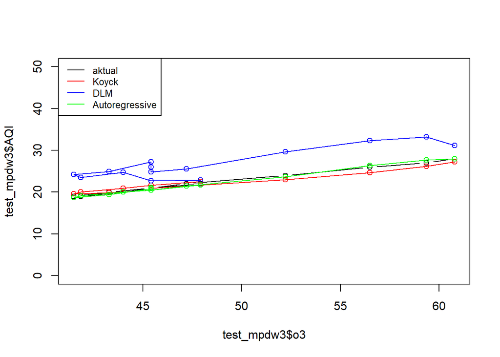

```r
par(mfrow=c(1,1))
plot(test_mpdw3$o3, test_mpdw3$AQI, type="b", col="black", ylim=c(0,50))
points(test_mpdw3$o3, fore_koyck$forecasts,col="red")
lines(test_mpdw3$o3, fore_koyck$forecasts,col="red")
points(test_mpdw3$o3, fore_dlm$forecasts,col="blue")
lines(test_mpdw3$o3, fore_dlm$forecasts,col="blue")
points(test_mpdw3$o3, fore_ardl$forecasts,col="green")
lines(test_mpdw3$o3, fore_ardl$forecasts,col="green")
legend("topleft",c("aktual", "Koyck","DLM", "Autoregressive"), lty=1, col=c("black","red","blue","green"), cex=0.8)
```

Melihat dari plot diatas, model ARDL adlaah model yang paling mendekati aktualnya, diikuti dengan model Koyck. Dan dapat dilihat model DLM sangat melenceng